# ANLY 545_50 HW_3

Mahesh

December 16, 2018

## Exercise 4.2

**a)**

```r
data("Abortion", package = "vcdExtra")
str(Abortion)
```

```
##  table [1:2, 1:2, 1:2] 171 152 138 167 79 148 112 133
##  - attr(*, "dimnames")=List of 3
##   ..$ Sex             : chr [1:2] "Female" "Male"
##   ..$ Status          : chr [1:2] "Lo" "Hi"
##   ..$ Support_Abortion: chr [1:2] "Yes" "No"
```

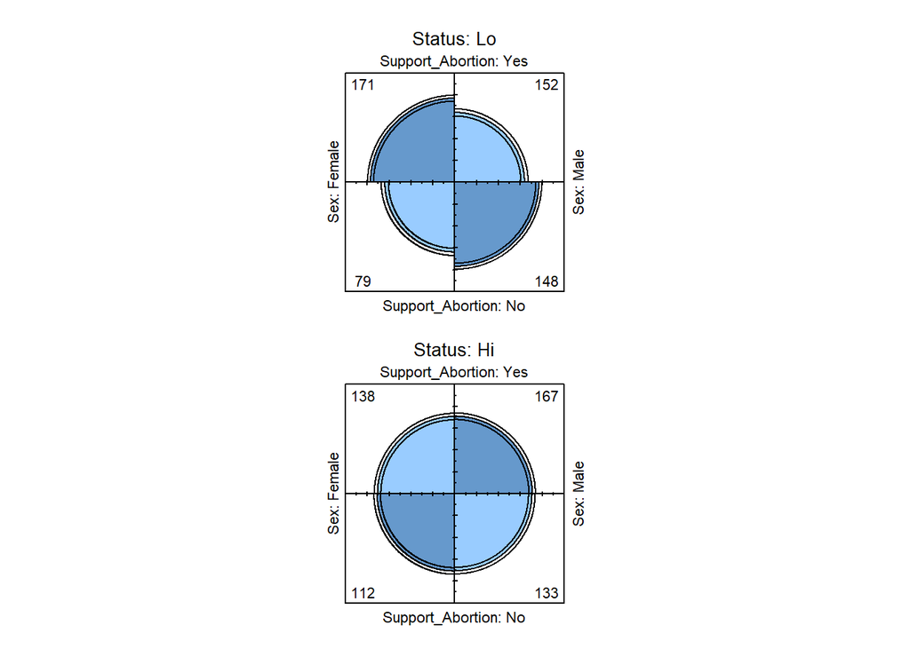

```r
fourfoldplot(aperm(Abortion, c(3,1,2)))
```

**b)**

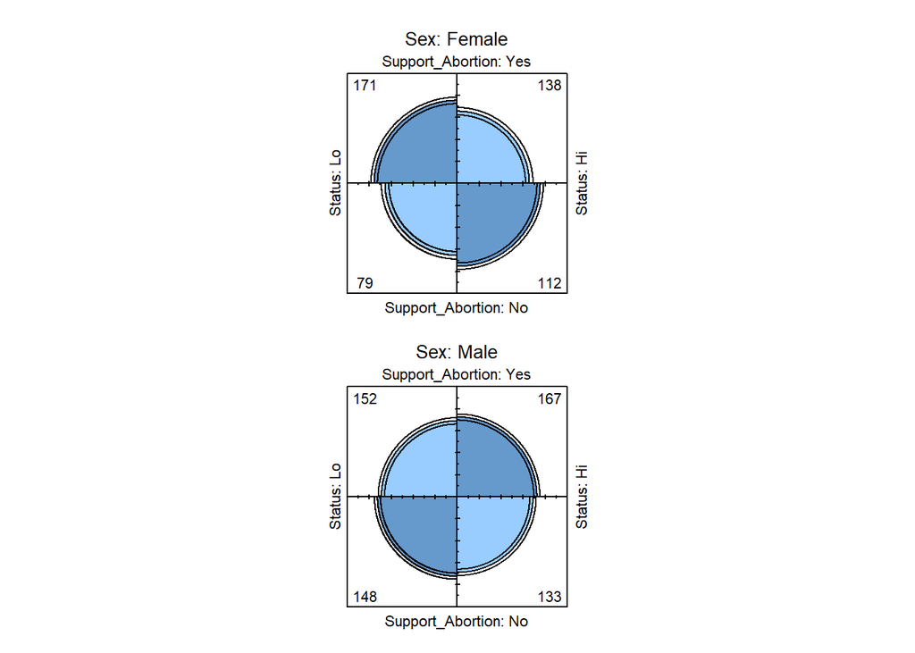

```r
fourfoldplot(aperm(Abortion, c(3,2,1)))
```

**c)**

```r
##OddsRatio(aperm(Abortion, c(3,1,2)))
##OddsRatio(aperm(Abortion, c(3,2,1)))
```

**d)**

When the status is Lo; more Females are supportive of Abortion compared to Males (171 vs 152). However, when the status is Hi, more males support Abortion compared to Females (167 vs 138). Overall, more people support Abortion when their status is Lo.

## Exercise 4.4

**a)**

```r
library(vcd)
data(Hospital)
chisq.test(Hospital)
```

```
##
##  Pearson's Chi-squared test
##
## data:  Hospital
## X-squared = 35.171, df = 4, p-value = 4.284e-07
```

**b)**

```r
Association = assocstats(Hospital)
Association
```

```
##                     X^2 df   P(> X^2)
## Likelihood Ratio 38.353  4 9.4755e-08
## Pearson          35.171  4 4.2842e-07
##
## Phi-Coefficient   : NA
## Contingency Coeff.: 0.459
## Cramer's V        : 0.365
```

**c)**

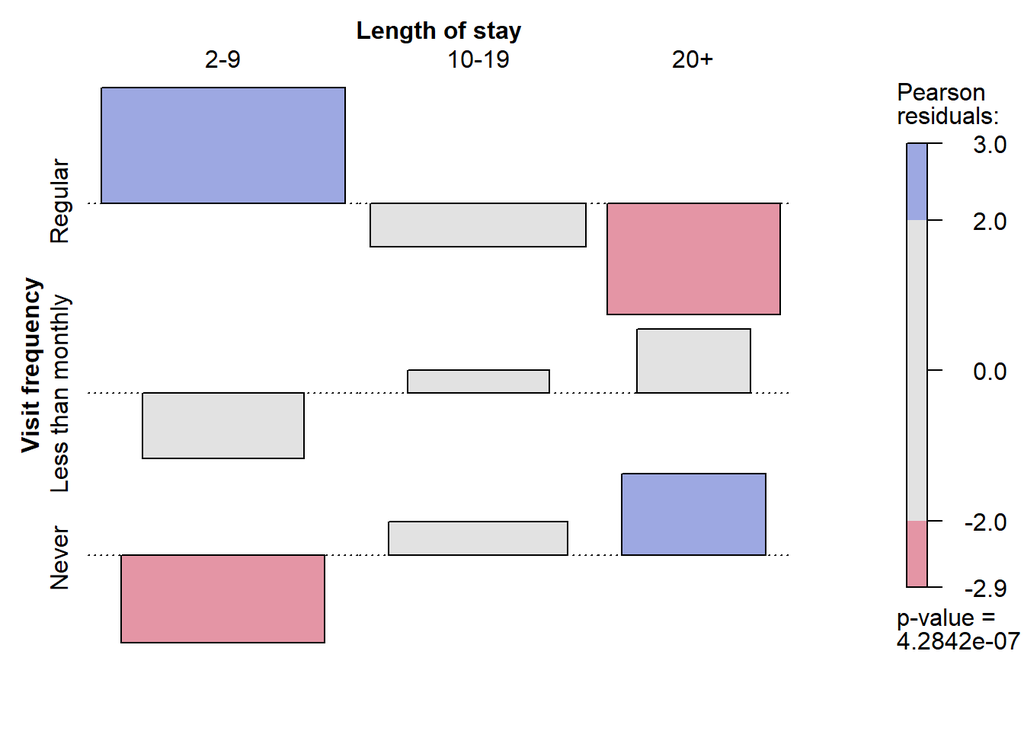

```r
assoc(Hospital, shade = TRUE)
```

From the residuals of the plot above, we see that LOS of 20+ has low assoiation for Regular visits and a high association for regular visits for LOS 2-9.

**d)**

```r
library(vcdExtra)
CMHtest(Hospital)
```

```
## Cochran-Mantel-Haenszel Statistics for Visit frequency by Length of stay
##
##                  AltHypothesis  Chisq Df       Prob
## cor        Nonzero correlation 29.138  1 6.7393e-08
## rmeans  Row mean scores differ 34.391  2 3.4044e-08
## cmeans  Col mean scores differ 29.607  2 3.7233e-07
## general    General association 34.905  4 4.8596e-07
```

## Exercise 4.6

```r
library(vcdExtra)
data(Mammograms)
Kappa(Mammograms, weights = "Fleiss-Cohen")
```

```
##             value     ASE      z  Pr(>|z|)
## Unweighted 0.3713 0.06033  6.154 7.560e-10
## Weighted   0.7641 0.03996 19.122 1.667e-81
```

Probability is low and there is significance int he test

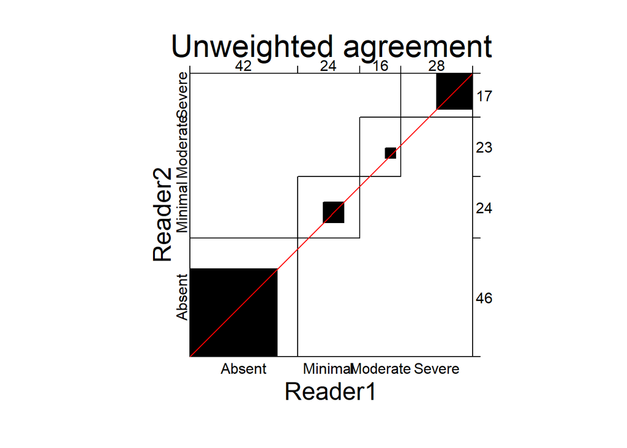

```r
agreementplot(Mammograms, main = "Unweighted agreement", weights = 1)
```

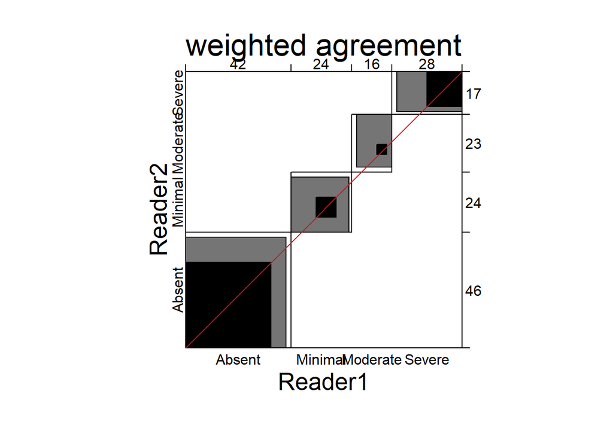

```r
agreementplot(Mammograms, main = "weighted agreement")
```

```r
assocstats(Mammograms)
```

```
##                     X^2 df   P(> X^2)
## Likelihood Ratio 92.619  9 4.4409e-16
## Pearson          83.516  9 3.2307e-14
##
## Phi-Coefficient   : NA
## Contingency Coeff.: 0.657
## Cramer's V        : 0.503
```

Kappa test gives us a measure of agreement but association statistics measures the association itself.

## Exercise 4.7

```r
Ratings = matrix(c(24,8,13,45,8,13,11,32,10,9,64,83,42,30,88,160), ncol = 4, byrow = T)

colnames(Ratings) = c("Con", "Mixed", "Pro", "Total")

rownames(Ratings) = c("Con", "Mixed", "Pro", "Total")
```

```r
Kappa(Ratings)
```

```
##              value     ASE     z Pr(>|z|)
## Unweighted 0.09012 0.02882 3.127 0.001767
## Weighted   0.08737 0.03372 2.591 0.009573
```

There are significance differences due to the low p value. Relevances to null hypothesis are just 0.1% and 0.9% respectively.

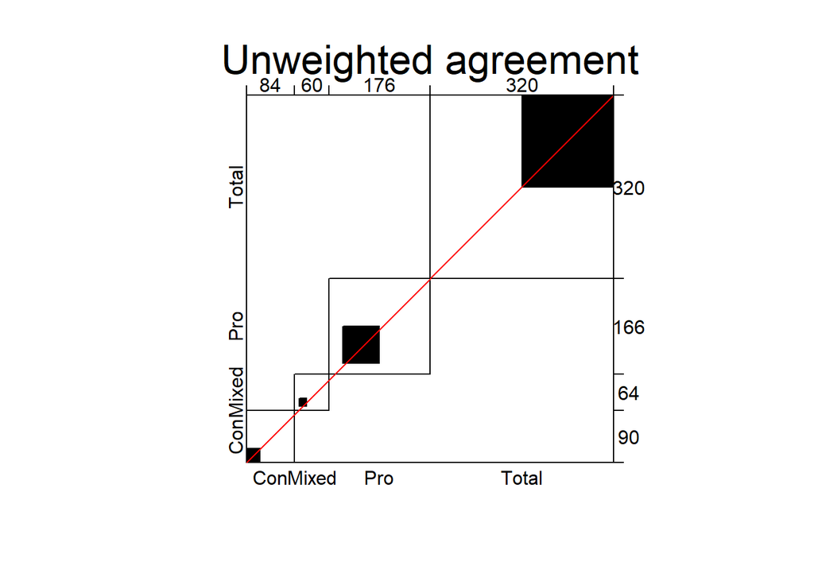

```r
agreementplot(Ratings, main = "Unweighted agreement", weights = 1)
```

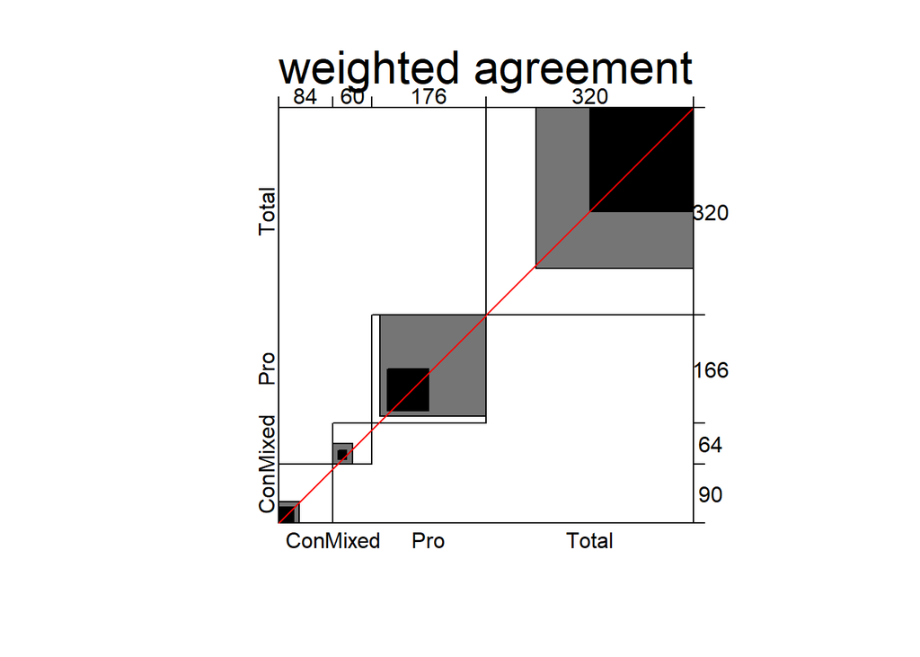

```r
agreementplot(Ratings, main = "weighted agreement")
```